# CRISPhieRmix vignette

Timothy Daley

2/2/2018

CRISPhieRmix is an R package to fit a hierarchical mixture model to the log fold changes obtained from a pooled CRISPR inhibition (CRISPRi) or CRISPR activation (CRISPRa) experiment. CRISPhieRmix computes gene-level probabilities that each gene is interesting. CRISPhieRmix has two methods, depending on whether or not negative control guides are available. Without negative control guides, CRISPhieRmix will fit a hierarchical normal mixture model. With negative control guides, CRISPhieRmix will compute a semi-parametric fit to the negative control guides and use this to fit a hierarchical mixture model.

We typically suggest that the log fold changes be calculated by DESeq2, edgeR, or some other tool to compute moderated fold changes to take sequencing depth effects into account.

In this vignette, we’ll walk through the analysis of the data using a semi-simulated data set from [Rosenbluh et al. 2017](https://www.ncbi.nlm.nih.gov/pmc/articles/PMC5457492/). This data is available with the CRISPhieRmix package.

```r
devtools::install_github("timydaley/CRISPhieRmix")
library(CRISPhieRmix)
data(Rosenbluh2017CRISPRiSim)
summary(Rosenbluh2017CRISPRiSim)
```

```
##         Length Class      Mode
## log2fc  9185   -none-     numeric
## geneIds 9185   factor     numeric
## negCtrl  959   -none-     numeric
## counts     6   data.frame list
```

```r
Rosenbluh2017CRISPRiSim.essential = data.frame(gene = unique(Rosenbluh2017CRISPRiSim$geneIds),
                                                essential = 1 - grepl("sim", unique(Rosenbluh2017CRISPRiSim$geneIds)))
Rosenbluh2017CRISPRiSim.essential$gene = factor(Rosenbluh2017CRISPRiSim.essential$gene, levels = unique(Rosenbluh2017CRISPRiSim.essential$gene))
```

The variable log2fc contains the DESeq2 computed log2 fold changes for the gene targeting guides, including both real genes and simulated negative genes; the variable geneIds contain the corresponding gene labels, with negative genes starting with “sim”; the variable negCtrl contains the DESeq2 log2 fold changes for the negative control guides; and counts contains the count matrix calculated from Supplementary Table 7 at https://www.ncbi.nlm.nih.gov/pmc/articles/PMC5457492/. For completeness, I will show how to obtain the log2 fold changes from the raw counts.

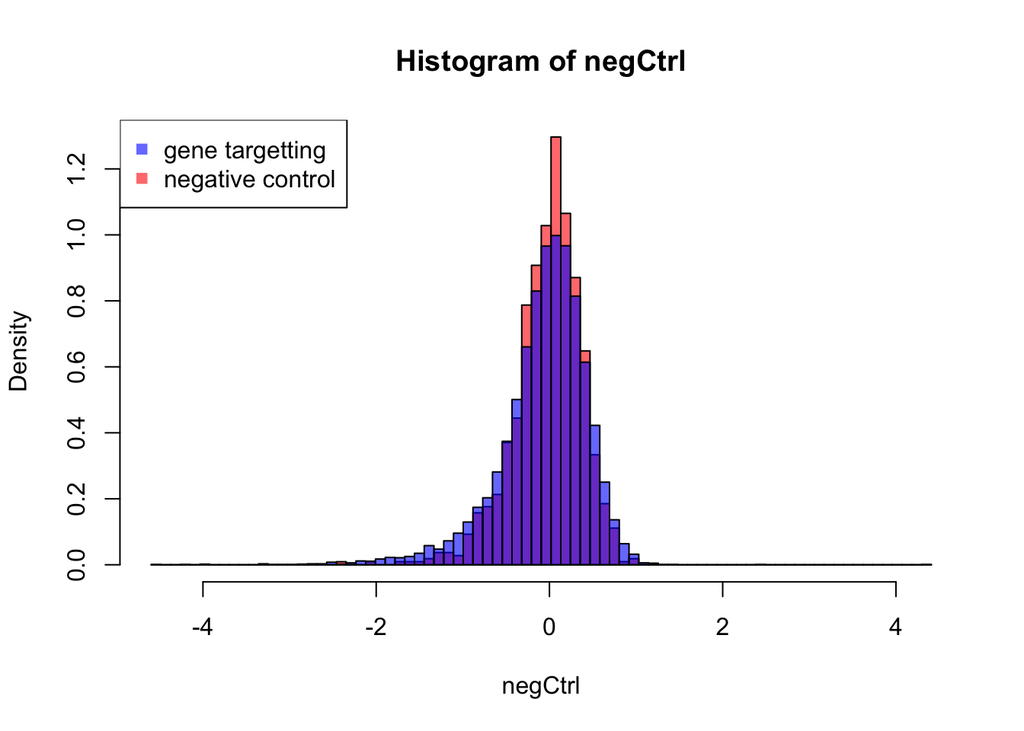

```r
library(DESeq2)
counts = Rosenbluh2017CRISPRiSim$counts[ ,4:6]
coldata = data.frame(condition = c(0, 1, 1))
rownames(coldata) = colnames(counts)
Rosenbluh2017CRISPRiSimDESeq = DESeq2::DESeqDataSetFromMatrix(countData = counts,
                                                                colData = coldata,
                                                                design = ~ condition)
Rosenbluh2017CRISPRiSimDESeq = DESeq2::DESeq(Rosenbluh2017CRISPRiSimDESeq)
Rosenbluh2017CRISPRiSimDESeq = DESeq2::results(Rosenbluh2017CRISPRiSimDESeq)
log2fc = Rosenbluh2017CRISPRiSimDESeq$log2FoldChange
b = seq(from = min(log2fc) - 0.1, to = max(log2fc) + 0.1, length = 81)
negCtrl = log2fc[which(Rosenbluh2017CRISPRiSim$counts$Category == "control")]
log2fc = log2fc[-which(Rosenbluh2017CRISPRiSim$counts$Category == "control")]
geneIds = Rosenbluh2017CRISPRiSim$counts$Gene[-which(Rosenbluh2017CRISPRiSim$counts$Category == "control")]
geneIds = factor(geneIds, levels = unique(geneIds))
hist(negCtrl, breaks = b, probability = TRUE, col = rgb(1, 0, 0, 0.6))
hist(log2fc, breaks = b, probability = TRUE, add = TRUE, col = rgb(0, 0, 1, 0.6))
legend("topleft", legend = c("gene targetting", "negative control"), col = c(rgb(0, 0, 1, 0.6), rgb(1, 0, 0, 0.6)), pch = 15)
```

```r
cor(log2fc, Rosenbluh2017CRISPRiSim$log2fc)
```

```
## [1] 1
```

Now let’s fit CRISPhieRmix to the log2 fold changes, including the VERBOSE and PLOT flags to look at the fit.

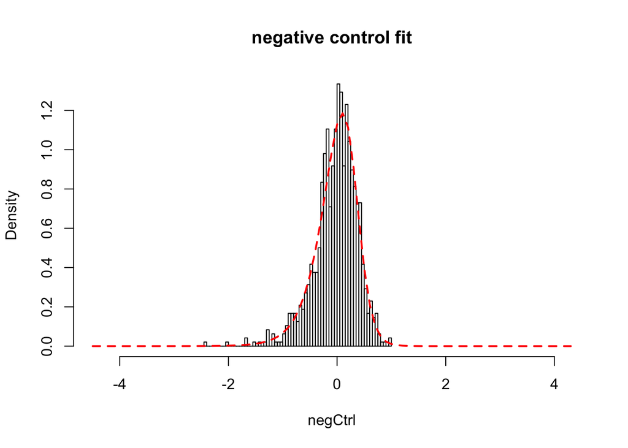

```
## fit negative control distributions
## 2 groups
## EM converged
## mu =  -0.5332737
## sigma =  0.8474482
## pq =  0.1171113
```

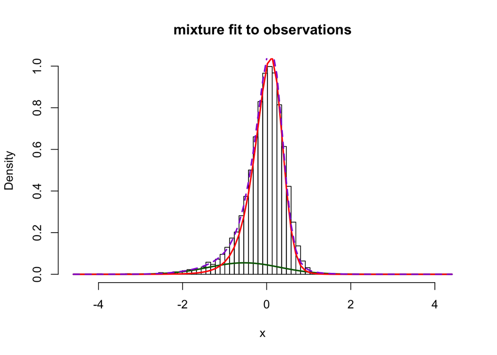

```r
log2fcCRISPhieRmixFit = CRISPhieRmix(log2fc, geneIds = geneIds, negCtrl = negCtrl, mu = -2, nMesh = 100, PLOT = TRUE, VERBOSE = TRUE)
```

```r
log2fcCRISPhieRmixScores = data.frame(gene = log2fcCRISPhieRmixFit$genes, locfdr = log2fcCRISPhieRmixFit$locfdr, score = log2fcCRISPhieRmixFit$genePosterior)
log2fcCRISPhieRmixScores$locfdr[which(log2fcCRISPhieRmixScores$locfdr < 0)] = 0
log2fcCRISPhieRmixScores = log2fcCRISPhieRmixScores[order(log2fcCRISPhieRmixScores$locfdr, decreasing = FALSE), ]
head(log2fcCRISPhieRmixScores, 20)
```

```
##            gene       locfdr     score
## BRAF       BRAF 0.000000e+00 1.0000000
## HNF1B     HNF1B 0.000000e+00 1.0000000
## POLR2D   POLR2D 0.000000e+00 1.0000000
## RPL4       RPL4 2.775558e-15 1.0000000
## PIK3CA   PIK3CA 1.887379e-13 1.0000000
## U2AF1     U2AF1 5.517808e-12 1.0000000
## MTOR       MTOR 2.593414e-11 1.0000000
## RPL5       RPL5 1.498776e-10 1.0000000
## RPL19     RPL19 2.812338e-10 1.0000000
## EGFR       EGFR 7.563158e-08 0.9999999
## RPL8       RPL8 2.783178e-07 0.9999997
## TCF7L2   TCF7L2 3.391885e-07 0.9999997
## PSMD2     PSMD2 4.192099e-05 0.9999581
## PCBP1     PCBP1 8.184541e-05 0.9999182
## KRAS       KRAS 1.159429e-04 0.9998841
## MAP2K1   MAP2K1 1.683081e-04 0.9998317
## RPTOR     RPTOR 1.076113e-02 0.9892389
## POLR1C   POLR1C 8.908712e-02 0.9109129
## SMARCA2 SMARCA2 4.431577e-01 0.5568423
## CTNNB1   CTNNB1 5.053557e-01 0.4946443
```

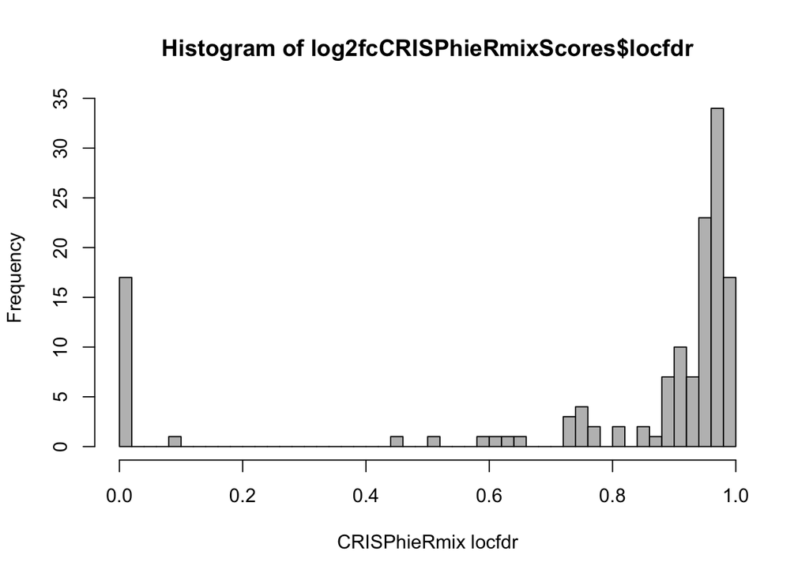

```r
hist(log2fcCRISPhieRmixScores$locfdr, breaks = 50, col = "grey", xlab = "CRISPhieRmix locfdr")
```

```r
estimatedFdr = sapply(1:dim(log2fcCRISPhieRmixScores)[1], function(i) mean(log2fcCRISPhieRmixScores$locfdr[1:i]))

fdr.curve <- function(thresh, fdrs, baseline){
  w = which(fdrs < thresh)
  if(length(w) > 0){
    return(sum(1 - baseline[w])/length(w))
  }
  else{
    return(NA)
  }
}
```

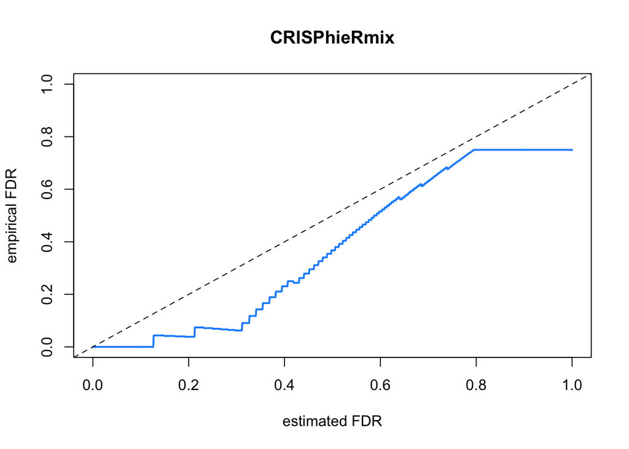

```r
s = seq(from = 0, to = 1, length = 1001)
f = sapply(s, function(t) fdr.curve(t, estimatedFdr, Rosenbluh2017CRISPRiSim.essential$essential[match(log2fcCRISPhieRmixScores$gene, Rosenbluh2017CRISPRiSim.essential$gene)]))
plot(c(0, s[!is.na(f)]), c(0, f[!is.na(f)]), type = "l", xlab = "estimated FDR", ylab = "empirical FDR", main = "CRISPhieRmix", xlim = c(0, 1), ylim = c(0, 1), lwd = 2, col = "dodgerblue")
abline(0, 1, lty = 2)
```

```
## no negative controls provided, fitting hierarchical normal model
```

```
## mixtools package, version 1.1.0, Released 2017-03-10
## This package is based upon work supported by the National Science Foundation under Grant No. SES-0518772.
```

```
## number of iterations= 104
```

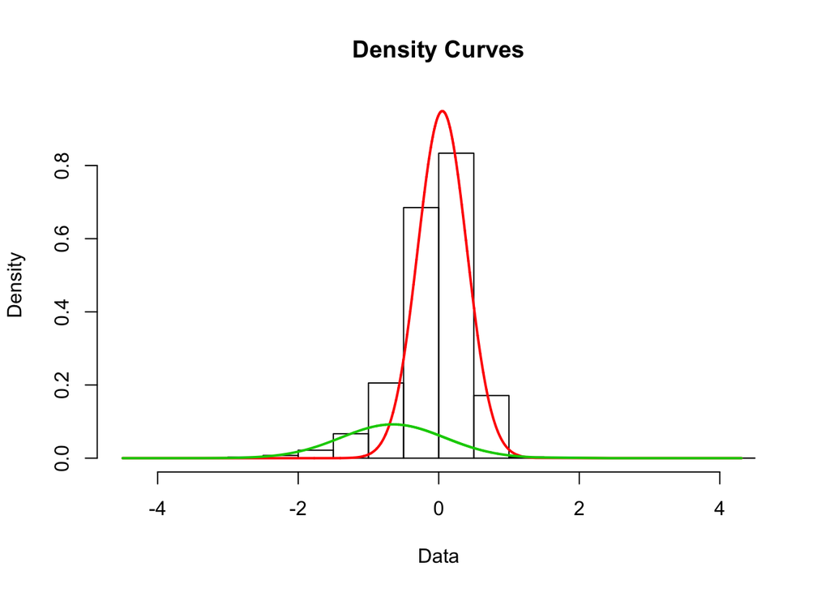

```r
log2fcNormalMixFit = CRISPhieRmix(log2fc, geneIds = geneIds, mu = -2, nMesh = 100, PLOT = TRUE, VERBOSE = TRUE)
```

```r
log2fcNormalMixScores = data.frame(gene = log2fcNormalMixFit$genes, locfdr = log2fcNormalMixFit$locfdr)
log2fcNormalMixScores = log2fcNormalMixScores[order(log2fcNormalMixScores$locfdr, decreasing = FALSE), ]
head(log2fcNormalMixScores, 20)
```

```
##            gene       locfdr
## BRAF       BRAF 0.000000e+00
## EGFR       EGFR 0.000000e+00
## HNF1B     HNF1B 0.000000e+00
## KRAS       KRAS 0.000000e+00
## MAP2K1   MAP2K1 0.000000e+00
## MTOR       MTOR 0.000000e+00
## PCBP1     PCBP1 0.000000e+00
## PIK3CA   PIK3CA 0.000000e+00
## POLR2D   POLR2D 0.000000e+00
## PSMD2     PSMD2 0.000000e+00
## RPL19     RPL19 0.000000e+00
## RPL4       RPL4 0.000000e+00
## RPL5       RPL5 0.000000e+00
## RPL8       RPL8 0.000000e+00
## RPTOR     RPTOR 0.000000e+00
## SMARCA2 SMARCA2 0.000000e+00
## TCF7L2   TCF7L2 0.000000e+00
## U2AF1     U2AF1 0.000000e+00
## POLR1C   POLR1C 1.032446e-07
## CTNNB1   CTNNB1 7.744774e-05
```

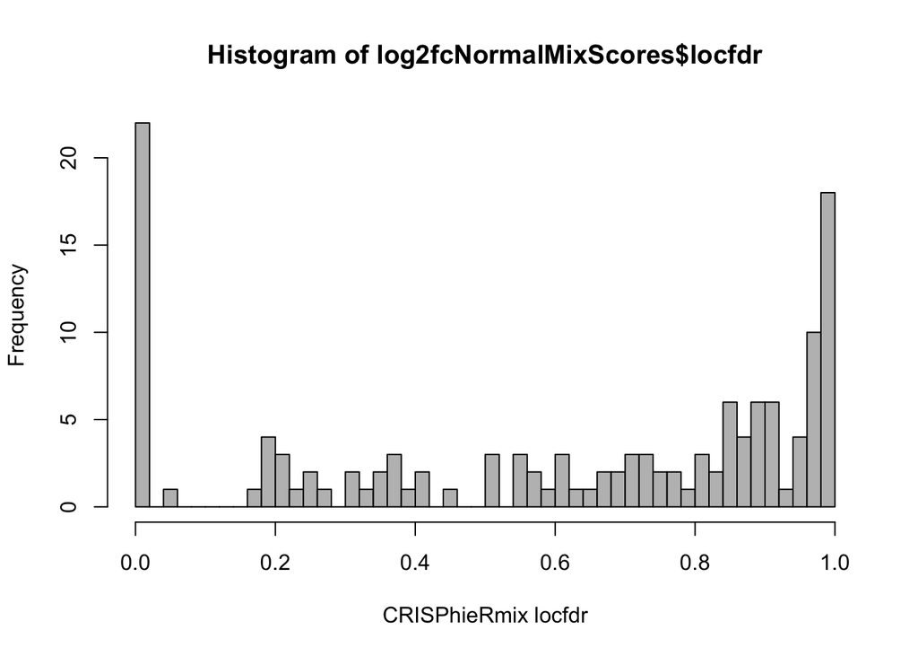

```r
hist(log2fcNormalMixScores$locfdr, breaks = 50, col = "grey", xlab = "CRISPhieRmix locfdr")
```

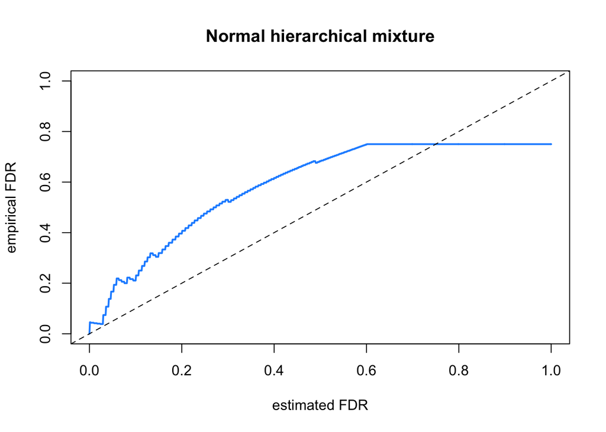

```r
estimatedFdr = sapply(1:dim(log2fcNormalMixScores)[1], function(i) mean(log2fcNormalMixScores$locfdr[1:i]))

f = sapply(s, function(t) fdr.curve(t, estimatedFdr, Rosenbluh2017CRISPRiSim.essential$essential[match(log2fcNormalMixScores$gene, Rosenbluh2017CRISPRiSim.essential$gene)]))
plot(c(0, s[!is.na(f)]), c(0, f[!is.na(f)]), type = "l", xlab = "estimated FDR", ylab = "empirical FDR", main = "Normal hierarchical mixture", xlim = c(0, 1), ylim = c(0, 1), lwd = 2, col = "dodgerblue")
abline(0, 1, lty = 2)
```

```r
cor(log2fcNormalMixFit$locfdr, log2fcCRISPhieRmixFit$locfdr, method = "spearman")
```

```
## [1] 0.9388555
```